# Women Entrepreneurship by Country

Adriana Picoral

12/1/2020

# Introduction

In this paper, I will discuss the effect of having women entrepreneurs on a country’s economy.

# Methods

## Research Questions

My research questions are as follows:

1. What is the relationship between having entrepreneurs in a country (no matter the gender) and that country’s economy?
2. What is the relationship between having **women** entrepreneurs in a country and that country’s economy?
3. Do women entrepreneurship index have a greater impact in the economy of a country than just entrepreneurs in general?

## Data

The data I am using was obtained from [Kaggle](https://www.kaggle.com/babyoda/women-entrepreneurship-and-labor-force) and contains the following variables: no, country, level_of_development, european_union_membership, currency, women_entrepreneurship_index, entrepreneurship_index, inflation_rate, female_labor_force_participation_rate. The data was collected from the year 2015 from 51 countries.

# Analysis

The two variables we have available in the data regarding economic development are: 1) a binary variable called *level_of_development* (i.e., Developed vs. Developing) and 2) *inflation_rate*. The first step in the analysis is to establish whether inflation rate is lower or higher for developed countries, assuming that developed countries have better economies.

The box plot below shows that *developed* countries have a lower inflation rate than *developing* countries. Thus, we assume that the lower the inflation rate, the stronger a country’s economy is.

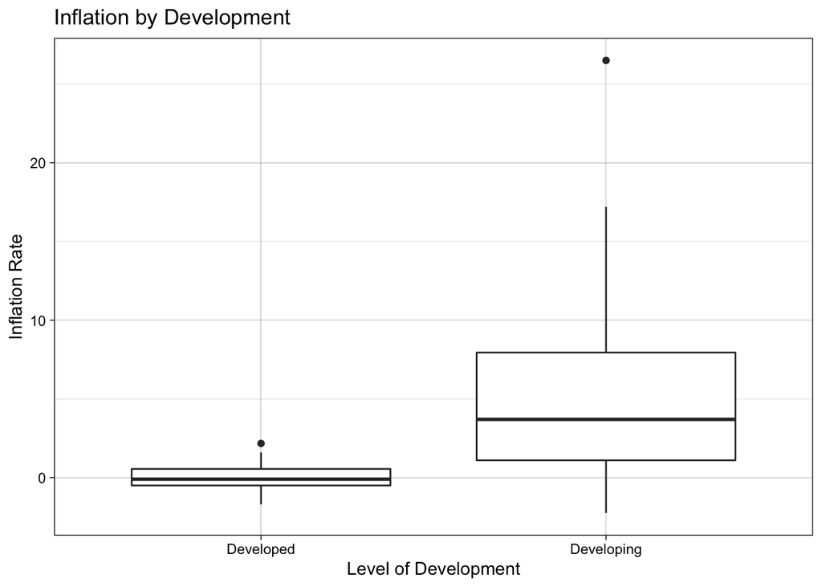

To answer my first research question (i.e., *What is the relationship between having entrepreneurs in a country (no matter the gender) and that country’s economy?*), we need to establish the relationship between inflation and entrepreneurship index.

The scatter plot below shows that as entrepreneurship increases, inflation rate decreases, indicating that more people owning business is good for the economy of a country.

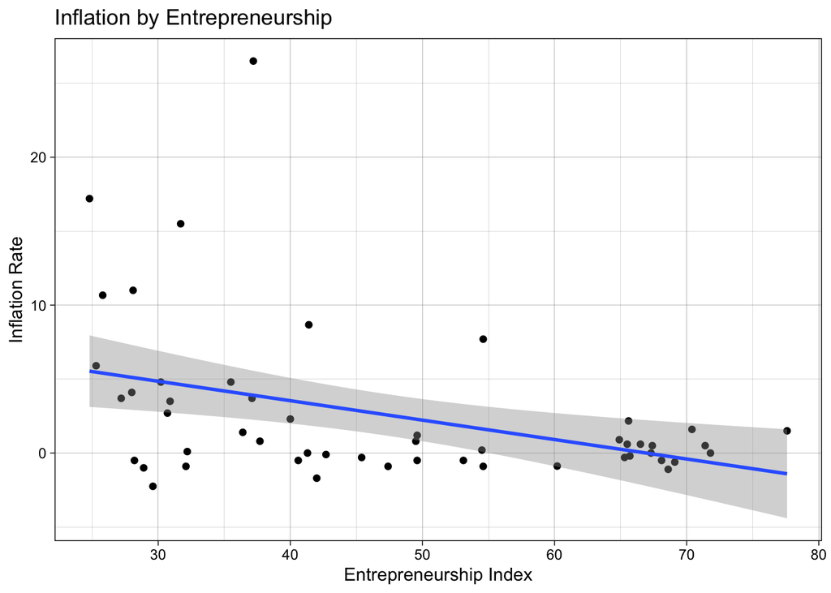

The table below shows that the relationship between inflation and entrepreneurship is negative, with inflation going down -0.13 points for every point increase in entrepreneurship index. The linear regression model explains 13.91% of the variation in the data.

|  | Estimate | Std. Error | t value | Pr(>\|t\|) |
| --- | --- | --- | --- | --- |
| (Intercept) | 8.793863 | 2.1751516 | 4.042874 | 0.0001862 |
| entrepreneurship_index | -0.131373 | 0.0436008 | -3.013090 | 0.0040851 |

To answer my second research question (i.e. *What is the relationship between having **women** entrepreneurs in a country and that country’s economy?*), we need to establish the relationship between inflation rate and women entrepreneurship index.

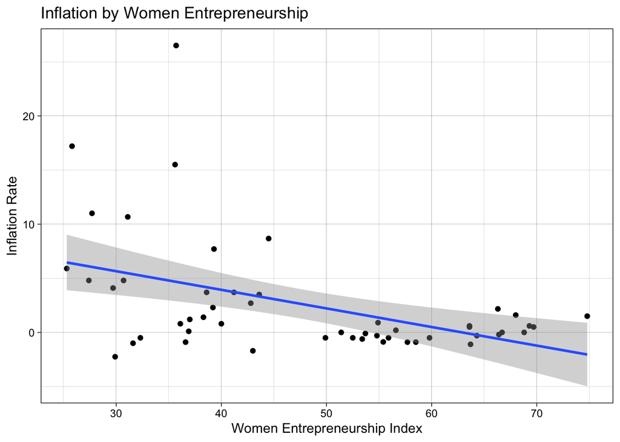

The table below shows that the relationship between inflation and women entrepreneurship is negative, with inflation going down -0.17 points for each additional point in women entrepreneurship index. This linear regression models explains 19.13% of the variation in the data.

|  | Estimate | Std. Error | t value | Pr(>\|t\|) |
| --- | --- | --- | --- | --- |
| (Intercept) | 10.8048470 | 2.3920152 | 4.517048 | 0.0000396 |
| women_entrepreneurship_index | -0.1717811 | 0.0479573 | -3.581957 | 0.0007823 |

Finally, to answer my third research question (i.e., *Do women entrepreneurship index have a greater impact in the economy of a country than just entrepreneurs in general?*), based on the two analysis here (i.e., inflation rate by entrepreneurship index and inflation rate by women entrepreneurship index) we see that the model for inflation rate by women entrepreneurship index explains more of the variance than the first model. Also, inflation rate goes down at a higher rate for every point increase in women entrepreneurship.

# Conclusion

In this analysis, I tried to show that women owning business (as represented by the women entrepreneurship index) helps a country’s economy (as represented by inflation rate). Results shows that indeed inflation goes down when women entrepreneurship index goes up (at a higher rate than just entrepreneurship in general).